# grupo2-trabalho3

Unidade Curricular : Métodos Estatísticos

```r
# Funcoes

# Stuges
sturges <- function(x)
{
  floor((1 + log(length(x)) / log(2)))
}

# Amplitude
amplitude <- function(x)
{
  max <- max(x)
  min <- min(x)
  nclass <- sturges(x)
  (max -min) / nclass
}
```

```r
# importar dataset
# alterar caminho para o vosso
# importar dataset
hour.dataset <- "D:/LEI/matematica/Metodos_Estatisticos/2122/ME_Trabalhos_2122/hour.csv"

# Todos os alugueres todas as horas
hour <- read.csv(file = hour.dataset)



# Todos os alugueres entre as 7 às 18
hour.day <- subset(hour, 6<hr & hr<19)

# Todos os alugueres entre as 19 às 6
hour.night <- subset(hour, hr>18 | hr<7)

# Ver tabelas importadas no RStudio
View(hour)
```

## **2. Dados em Estudo**

A nossa análise irá contemplar o aluguer de bicicletas em Washington usando os métodos matemáticos sobre regressão linear simples.

### **Escolha da Variável**

A variável em estudo é a temperatura (temp) e é uma variável contínua.

### **Tabela de Frequência e Histograma**

Para a escolha da variável, fez-se os cálculos necessários para a criação da tabela de frequências.

```r
# min max
cat("Mínimo\n")
```

```
## Mínimo
```

```r
hour.temp.min <- min(hour$temp)
hour.temp.min
```

```
## [1] 0.02
```

```r
cat("\nMáximo\n")
```

```
##
## Máximo
```

```r
hour.temp.max <- max(hour$temp)
hour.temp.max
```

```
## [1] 1
```

```r
# formula de sturges
cat("\nNúmero de classes\n")
```

```
##
## Número de classes
```

```r
hour.temp.sturges.nclass <- sturges(hour$temp)
hour.temp.sturges.nclass
```

```
## [1] 15
```

```r
# amplitude da classe
cat("\nAmplitude da classe\n")
```

```
##
## Amplitude da classe
```

```r
hour.temp.sturges.amplitude <- amplitude(hour$temp)
hour.temp.sturges.amplitude
```

```
## [1] 0.06533333
```

```r
# tabela de frequencias
cat("\nClasses\n")
```

```
##
## Classes
```

```r
hour.temp.sturges.breaks <- seq(hour.temp.min, hour.temp.max, hour.temp.sturges.amplitude)
hour.temp.sturges.breaks
```

```
##  [1] 0.02000000 0.08533333 0.15066667 0.21600000 0.28133333 0.34666667
##  [7] 0.41200000 0.47733333 0.54266667 0.60800000 0.67333333 0.73866667
## [13] 0.80400000 0.86933333 0.93466667 1.00000000
```

```r
cat("\nTabela de frequências")
```

```
##
## Tabela de frequências
```

```r
table(cut(hour$temp, breaks=hour.temp.sturges.breaks))
```

```
##
##  (0.02,0.0853] (0.0853,0.151]  (0.151,0.216]  (0.216,0.281]  (0.281,0.347]
##             49            265            739           1803           1897
##  (0.347,0.412]  (0.412,0.477]  (0.477,0.543]  (0.543,0.608]  (0.608,0.673]
##           1657           1614           1944           1559           2111
##  (0.673,0.739]  (0.739,0.804]  (0.804,0.869]  (0.869,0.935]      (0.935,1]
##           1609           1406            482            192             34
```

Após a criação da tabela de frequências, calculou-se a média e variância da variável temp, e de seguida criou-se o seu histograma, de forma a ser possível tirar conclusões.

```r
# media e variancia
cat("\nMédia\n")
```

```
##
## Média
```

```r
x <- mean(hour$temp)
x
```

```
## [1] 0.4969872
```

```r
cat("\nVariância\n")
```

```
##
## Variância
```

```r
s <- var(hour$temp)
s
```

```
## [1] 0.03707786
```

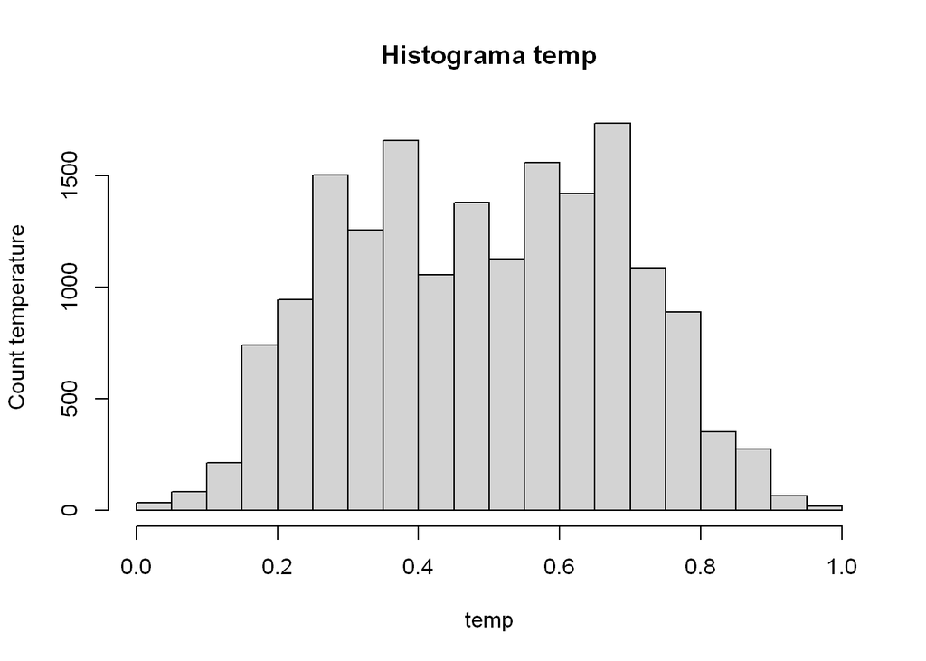

```r
# histograma
hist(hour$temp, main="Histograma temp", xlab="temp",  ylab="Count temperature", nclass=hour.temp.sturges.nclass)
```

Média = 0.4969872 Variância = 0.03707786

A nossa distribuição Normal contabiliza a temperatura (temp), em horas (17379) num periodo de 2 anos, num aluguer de bicicletas.

### **Hipóteses**

H0 − Os dados provêm da população com a distribuição Normal.

H1 − Os dados não provêm da população com a distribuição Normal.

```r
var(hour$temp)
```

```
## [1] 0.03707786
```

```r
mean(hour$temp)
```

```
## [1] 0.4969872
```

```r
chisq.test(table(hour$temp))
```

```
##
##  Chi-squared test for given probabilities
##
## data:  table(hour$temp)
## X-squared = 8694.5, df = 49, p-value < 2.2e-16
```

```r
qchisq(.90,  df=49)
```

```
## [1] 62.03754
```

Dobs = 8694.5 e RC=[62.03754,+∞] No nível de significância de 10% tem como 2.2e-16 < 0.10 então rejeita-se a hipótese nula (H0).

Com base na amostra e ao nível de signifiância de 10%, conclui-se que os tempos de falha não seguem uma distribuição Normal.

```r
var(hour.day$temp)
```

```
## [1] 0.0401759
```

```r
mean(hour.day$temp)
```

```
## [1] 0.5236736
```

```r
chisq.test(table(hour.day$temp))
```

```
##
##  Chi-squared test for given probabilities
##
## data:  table(hour.day$temp)
## X-squared = 3883.3, df = 49, p-value < 2.2e-16
```

```r
qchisq(.90,  df=49)
```

```
## [1] 62.03754
```

Dobs = 3883.3 e RC=[62.03754,+∞]

No nível de significância de 10% tem como 2.2e-16 < 0.10 então rejeita-se a hipótese nula (H0).

Com base na amostra e ao nível de signifiância de 10%, conclui-se que os tempos de falha não seguem uma distribuição Normal.

```r
#df: graus de liberdade
var(hour.night$temp)
```

```
## [1] 0.03250075
```

```r
mean(hour.night$temp)
```

```
## [1] 0.4700012
```

```r
chisq.test(table(hour.night$temp))
```

```
##
##  Chi-squared test for given probabilities
##
## data:  table(hour.night$temp)
## X-squared = 4392.1, df = 45, p-value < 2.2e-16
```

```r
qchisq(.90, df=45)
```

```
## [1] 57.5053
```

Dobs = 4392.1 e RC=[57.5053,+∞]

No nível de significância de 10% tem como 2.2e-16 < 0.10 então rejeita-se a hipótese nula (H0).

Com base na amostra e ao nível de signifiância de 10%, conclui-se que os tempos de falha não seguem uma distribuição Normal.

### **Regressão Linear Simples**

O modelo de correlação linear estudado no trabalho anterior, entre as variáveis contínuas cnt (independente) e temp (dependente), comprova ter uma forte correlação linear, deste modo, os residuos por norma deverão de ter uma distribuição Normal.

```r
regressao <- lm(hour$temp ~ hour$cnt)
regressao
```

```
##
## Call:
## lm(formula = hour$temp ~ hour$cnt)
##
## Coefficients:
## (Intercept)     hour$cnt
##   0.4155758    0.0004297
```

```r
regressao2 <- lm(hour.day$temp ~ hour.day$cnt)
regressao3 <- lm(hour.night$temp ~ hour.night$cnt)


residuos <- resid(regressao)
residuos2 <- resid(regressao2)
residuos3 <- resid(regressao3)

cat("\nTabela de frequências")
```

```
##
## Tabela de frequências
```

```r
table(sort(residuos))
```

[output not shown]

[output cut: 6504 more lines]

[output not shown]

```r
cat("\nTabela de frequências de Dia")
```

```
##
## Tabela de frequências de Dia
```

```r
table(sort(residuos2))
```

[output not shown]

[output cut: 4524 more lines]

[output not shown]

```r
cat("\nTabela de frequências de Noite")
```

```
##
## Tabela de frequências de Noite
```

```r
table(sort(residuos3))
```

[output not shown]

[output cut: 3030 more lines]

[output not shown]

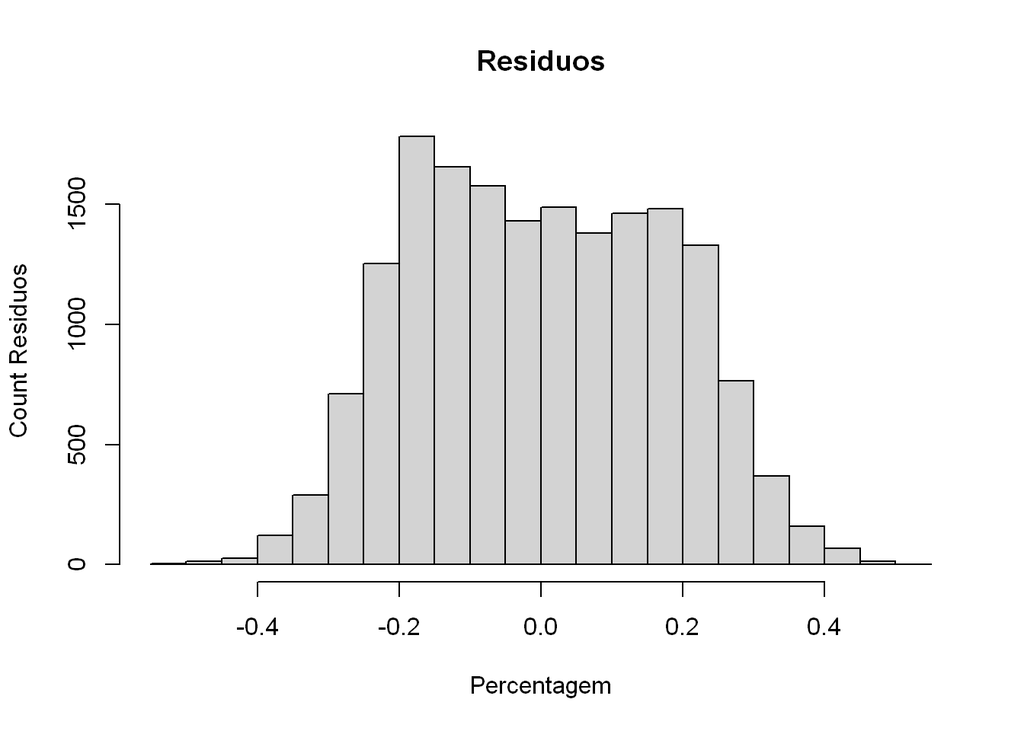

```r
hist(residuos, main="Residuos", xlab="Percentagem", ylab="Count Residuos")
```

### **Hipóteses** {#hipoteses}

H1 − Os dados não provêm da população com a distribuição Normal no teste de ajustamtamento de Kolmogorov-Smirnov.

### **Testes de Ajustamento**

Realização dos testes de ajustamento de Kolmogorov-Smirnov, assim como, através da região crítica e do valor-p

```r
ks.test(hour$temp, hour$cnt)
```

```
##
##  Two-sample Kolmogorov-Smirnov test
##
## data:  hour$temp and hour$cnt
## D = 0.99994, p-value < 2.2e-16
## alternative hypothesis: two-sided
```

```r
rc =1.36  / sqrt(length(residuos))
rc
```

```
## [1] 0.01031636
```

Dobs = 0.99994 e RC=[0.01031636,+∞] Como 0.99994 pertence à Região Critíca então rejeita se a hipótese H0.

Como valor-p < 2.2e-16 < 0.05 = α então rejeita se a hipotese nula.

```r
ks.test(hour.day$temp, hour.day$cnt)
```

```
##
##  Two-sample Kolmogorov-Smirnov test
##
## data:  hour.day$temp and hour.day$cnt
## D = 0.99989, p-value < 2.2e-16
## alternative hypothesis: two-sided
```

```r
rc =1.36  / sqrt(length(residuos2))
rc
```

```
## [1] 0.01454899
```

Dobs = 0.99989 e RC=[0.01454899,+∞] Como 0.99989 pertence à Região Critíca então rejeita se a hipótese H0.

Como valor-p < 2.2e-16 < 0.05 = α então rejeita se a hipotese nula.

Como Valor-P é um valor exato, ao qual consideramos fiável, concluindo que a H0 é rejeitada.

```r
ks.test(hour.night$temp, hour.night$cnt)
```

```
##
##  Two-sample Kolmogorov-Smirnov test
##
## data:  hour.night$temp and hour.night$cnt
## D = 1, p-value < 2.2e-16
## alternative hypothesis: two-sided
```

```r
rc =1.36  / sqrt(length(residuos3))
rc
```

```
## [1] 0.01463042
```

Dobs = 1 e RC=[0.01463042,+∞] Como 1 pertence à Região Critíca então rejeita a hipótese H0. Como valor-p < 2.2e-16 < 0.05 = α então rejeita se a hipotese nula.

### **Hipóteses**

H0 − As variáveis são independentes

H1 − As variáveis não são independentes

```r
dim(hour)
```

```
## [1] 17379    17
```

```r
#(tabela.1 <- table(hour))
#dimnames(table(hour)) = list(yr=c("Não","Sim"),
#                          workingday=c("Não","Sim"))
#tabela.1

# formula de sturges
cat("\nNúmero de classes\n")
```

```
##
## Número de classes
```

```r
hour.atemp.sturges.nclass <- sturges(hour$atemp)
hour.atemp.sturges.nclass
```

```
## [1] 15
```

```r
# amplitude da classe
cat("\nAmplitude da classe\n")
```

```
##
## Amplitude da classe
```

```r
hour.atemp.sturges.amplitude <- amplitude(hour$atemp)
hour.atemp.sturges.amplitude
```

```
## [1] 0.06666667
```

```r
(tabela.1 <- table(hour$season,hour$weathersit))
```

```
##
##        1    2    3    4
##   1 2665 1205  369    3
##   2 2859 1144  406    0
##   3 3280  947  269    0
##   4 2609 1248  375    0
```

```r
dimnames(tabela.1) = list(season=c("Inverno","Primavera", "Verão", "Outono"),
                        weathersit=c("Céu Limpo","Nublado", "Aguaceiros","Tempestade"))

hourdaynight <- chisq.test(tabela.1)
cat("\n Tabela de contigência dos dados observados\n")
```

```
##
##  Tabela de contigência dos dados observados
```

```r
hourdaynight$observed  # Oi = frequências Observadas
```

```
##            weathersit
## season      Céu Limpo Nublado Aguaceiros Tempestade
##   Inverno        2665    1205        369          3
##   Primavera      2859    1144        406          0
##   Verão          3280     947        269          0
##   Outono         2609    1248        375          0
```

```r
cat("\n Tabela de contigência dos dados esperados\n")
```

```
##
##  Tabela de contigência dos dados esperados
```

```r
hourdaynight$expected
```

```
##            weathersit
## season      Céu Limpo  Nublado Aguaceiros Tempestade
##   Inverno    2785.773 1109.134   346.3604  0.7322631
##   Primavera  2895.444 1152.799   359.9960  0.7610910
##   Verão      2952.578 1175.547   367.0996  0.7761091
##   Outono     2779.206 1106.520   345.5439  0.7305369
```

```r
cat("\nQobs\n")
```

```
##
## Qobs
```

```r
hourdaynight$statistic
```

```
## X-squared
##  168.6791
```

```r
cat("Graus de liberdade")
```

```
## Graus de liberdade
```

```r
hourdaynight$parameter # graus de liberdade
```

```
## df
##  9
```

```r
cat("\nP Value\n")
```

```
##
## P Value
```

```r
hourdaynight$p.value   # valor-p
```

```
## [1] 1.162626e-31
```

```r
#
#qchisq(.01, df=42532)
```

No nível de significância de 1% tem como 1.162626e-31 < 0.01 então rejeita-se a hipótese nula (H0).

### **Hipóteses**

H0 − As variáveis são independentes

H1 − As variáveis não são independentes

```r
(tabela.2 <- table(hour.day$season,hour.day$weathersit))
```

```
##
##        1    2    3    4
##   1 1345  620  190    2
##   2 1382  627  199    0
##   3 1615  502  138    0
##   4 1243  666  209    0
```

```r
dimnames(tabela.2) = list(season=c("Inverno","Primavera", "Verão", "Outono"),
                        weathersit=c("Céu Limpo","Nublado", "Aguaceiros","Tempestade"))

hourday <- chisq.test(tabela.2)
cat("\n Tabela de contigência dos dados observados\n")
```

```
##
##  Tabela de contigência dos dados observados
```

```r
hourday$observed  # Oi = frequências Observadas
```

```
##            weathersit
## season      Céu Limpo Nublado Aguaceiros Tempestade
##   Inverno        1345     620        190          2
##   Primavera      1382     627        199          0
##   Verão          1615     502        138          0
##   Outono         1243     666        209          0
```

```r
cat("\n Tabela de contigência dos dados esperados\n")
```

```
##
##  Tabela de contigência dos dados esperados
```

```r
hourday$expected
```

```
##            weathersit
## season      Céu Limpo  Nublado Aguaceiros Tempestade
##   Inverno    1378.673 596.1496   181.6837  0.4937057
##   Primavera  1411.270 610.2449   185.9794  0.5053788
##   Verão      1441.311 623.2347   189.9382  0.5161364
##   Outono     1353.746 585.3708   178.3987  0.4847791
```

```r
cat("\nQobs\n")
```

```
##
## Qobs
```

```r
hourday$statistic
```

```
## X-squared
##  94.36922
```

```r
cat("\nGraus de liberdade\n")
```

```
##
## Graus de liberdade
```

```r
hourday$parameter # graus de liberdade
```

```
## df
##  9
```

```r
cat("\nP Value\n")
```

```
##
## P Value
```

```r
hourday$p.value   # valor-p
```

```
## [1] 2.154533e-16
```

No nível de significância de 1% tem como 2.154533e-16 < 0.01 então rejeita-se a hipótese nula (H0).

### **Hipóteses**

H0 − As variáveis são independentes

H1 − As variáveis não são independentes

```r
(tabela.3 <- table(hour.night$season,hour.night$weathersit))
```

```
##
##        1    2    3    4
##   1 1320  585  179    1
##   2 1477  517  207    0
##   3 1665  445  131    0
##   4 1366  582  166    0
```

```r
dimnames(tabela.3) = list(season=c("Inverno","Primavera", "Verão", "Outono"),
                        weathersit=c("Céu Limpo","Nublado", "Aguaceiros","Tempestade"))

hournight <- chisq.test(tabela.3)
cat("\n Tabela de contigência dos dados observados\n")
```

```
##
##  Tabela de contigência dos dados observados
```

```r
hournight$observed  # Oi = frequências Observadas
```

```
##            weathersit
## season      Céu Limpo Nublado Aguaceiros Tempestade
##   Inverno        1320     585        179          1
##   Primavera      1477     517        207          0
##   Verão          1665     445        131          0
##   Outono         1366     582        166          0
```

```r
cat("\n Tabela de contigência dos dados esperados\n")
```

```
##
##  Tabela de contigência dos dados esperados
```

```r
hournight$expected
```

```
##            weathersit
## season      Céu Limpo  Nublado Aguaceiros Tempestade
##   Inverno    1406.247 513.7096   164.8021  0.2412915
##   Primavera  1484.484 542.2901   173.9710  0.2547159
##   Verão      1511.463 552.1455   177.1326  0.2593450
##   Outono     1425.806 520.8548   167.0943  0.2446476
```

```r
cat("\nQobs\n")
```

```
##
## Qobs
```

```r
hournight$statistic
```

```
## X-squared
##  85.13561
```

```r
cat("\nGraus de liberdade\n")
```

```
##
## Graus de liberdade
```

```r
hournight$parameter # graus de liberdade
```

```
## df
##  9
```

```r
cat("\nP Value\n")
```

```
##
## P Value
```

```r
hournight$p.value   # valor-p
```

```
## [1] 1.532833e-14
```

No nível de significância de 1% tem como 1.532833e-14 < 0.01 então rejeita-se a hipótese nula (H0).

## **3. Referências**

### 3.1 Documentação Não Eletrónia

1. O’Reilly, Hadley Wickham & Garrett Glomund - R for Data Science.(2021)